# Untitled

Muhammad Fadhil Hakim

2025-11-12

# Import Data dan Library

```r
library(tidyverse)
library(readxl)
library(lubridate)
library(caret)
library(factoextra)
library(cluster)
library(clusterCrit)
data <- read_excel("C:/prak/sem 5/TPG/Mall_Customers.xlsx")
data
```

```
## # A tibble: 200 × 3
##      Age `Annual Income (k$)` `Spending Score (1-100)`
##    <dbl>                <dbl>                    <dbl>
##  1    19                   15                       39
##  2    21                   15                       81
##  3    20                   16                        6
##  4    23                   16                       77
##  5    31                   17                       40
##  6    22                   17                       76
##  7    35                   18                        6
##  8    23                   18                       94
##  9    64                   19                        3
## 10    30                   19                       72
## # ℹ 190 more rows
```

```r
summary(data)
```

```
##       Age        Annual Income (k$) Spending Score (1-100)
##  Min.   :18.00   Min.   : 15.00     Min.   : 1.00
##  1st Qu.:28.75   1st Qu.: 41.50     1st Qu.:34.75
##  Median :36.00   Median : 61.50     Median :50.00
##  Mean   :38.85   Mean   : 60.56     Mean   :50.20
##  3rd Qu.:49.00   3rd Qu.: 78.00     3rd Qu.:73.00
##  Max.   :70.00   Max.   :137.00     Max.   :99.00
```

```r
str(data)
```

```
## tibble [200 × 3] (S3: tbl_df/tbl/data.frame)
##  $ Age                   : num [1:200] 19 21 20 23 31 22 35 23 64 30 ...
##  $ Annual Income (k$)    : num [1:200] 15 15 16 16 17 17 18 18 19 19 ...
##  $ Spending Score (1-100): num [1:200] 39 81 6 77 40 76 6 94 3 72 ...
```

```r
data1 <- na.omit(data)
data1
```

```
## # A tibble: 200 × 3
##      Age `Annual Income (k$)` `Spending Score (1-100)`
##    <dbl>                <dbl>                    <dbl>
##  1    19                   15                       39
##  2    21                   15                       81
##  3    20                   16                        6
##  4    23                   16                       77
##  5    31                   17                       40
##  6    22                   17                       76
##  7    35                   18                        6
##  8    23                   18                       94
##  9    64                   19                        3
## 10    30                   19                       72
## # ℹ 190 more rows
```

# Standarisasi dan Matriks Jarak

```r
data_scaled <- scale(data1)
data_scaled
```

```
##                Age Annual Income (k$) Spending Score (1-100)
##   [1,] -1.42100291        -1.73464625           -0.433713114
##   [2,] -1.27782881        -1.73464625            1.192711064
##   [3,] -1.34941586        -1.69657236           -1.711617825
##   [4,] -1.13465471        -1.69657236            1.037813523
##   [5,] -0.56195833        -1.65849848           -0.394988729
##   [6,] -1.20624176        -1.65849848            0.999089138
##   [7,] -0.27561014        -1.62042459           -1.711617825
##   [8,] -1.13465471        -1.62042459            1.696128071
##   [9,]  1.80041426        -1.58235070           -1.827790981
##  [10,] -0.63354538        -1.58235070            0.844191597
##  [11,]  2.01517540        -1.58235070           -1.401822744
##  [12,] -0.27561014        -1.58235070            1.889749997
##  [13,]  1.37089197        -1.54427682           -1.363098359
##  [14,] -1.06306766        -1.54427682            1.037813523
```

[output cut: 192 more lines]

```r
# Menghitung matriks jarak menggunakan metode Euclidean
distance_matrix <- dist(data_scaled, method = "euclidean")
head(distance_matrix,10)
```

```
##  [1] 1.6327138 1.2804744 1.4996118 0.8632819 1.4508077 1.7198871 2.1520375
##  [8] 3.5134279 1.5087491 3.5731991
```

```r
# Menentukan jumlah klaster optimal menggunakan metode Ward's
c_ward <- hclust(distance_matrix, method = "ward.D2")
c_ward
```

```
##
## Call:
## hclust(d = distance_matrix, method = "ward.D2")
##
## Cluster method   : ward.D2
## Distance         : euclidean
## Number of objects: 200
```

# Dendrogram

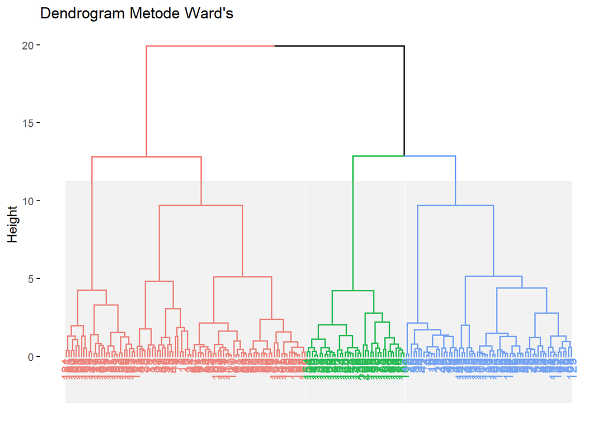

```r
fviz_dend(c_ward, k = 3,
            rect = TRUE,
            rect_fill = TRUE,
            main = "Dendrogram Metode Ward's")
```

# Hasil Clustering

```r
# Memotong dendrogram untuk mendapatkan 3 klaster
clusters <- cutree(c_ward, k = 3)
table(clusters)
```

```
## clusters
##  1  2  3
## 95 66 39
```

# Komponen Hasil

```r
names(c_ward)
```

```
## [1] "merge"       "height"      "order"       "labels"      "method"
## [6] "call"        "dist.method"
```

Pada fungsi hclust, beberapa komponen penting yang dihasilkan antara lain: 1. merge: Matriks yang menunjukkan bagaimana klaster digabungkan pada setiap langkah. 2. height: Vektor yang menunjukkan jarak pada setiap langkah penggabungan klaster. 3. order: Urutan objek dalam dendrogram. 4. labels: Label asli dari data yang digunakan. 5. method &dist.method : Metode penggabungan yang digunakan (dalam hal ini “ward.D2”). 6. call: Panggilan fungsi yang digunakan untuk menghasilkan objek hclust.

```r
c_ward$height
```

```
##   [1]  0.07158705  0.07158705  0.07744877  0.08985491  0.10546572  0.10546572
##   [7]  0.11212778  0.11422166  0.12060748  0.13008267  0.13645845  0.13800326
##  [13]  0.14317410  0.14709180  0.14831858  0.15200469  0.15312747  0.15546577
##  [19]  0.15626705  0.15714169  0.15756864  0.16277940  0.16277940  0.17483585
##  [25]  0.18524835  0.18685940  0.18720306  0.19948310  0.19948310  0.20157189
##  [31]  0.20354494  0.20534006  0.20703817  0.20991374  0.20991374  0.20991374
##  [37]  0.21172190  0.21248357  0.21290068  0.21476114  0.22740707  0.23145255
##  [43]  0.23170224  0.23185706  0.23463345  0.23496451  0.24066397  0.24132741
##  [49]  0.24250904  0.24348467  0.24608766  0.24711975  0.25253582  0.25256040
##  [55]  0.26159535  0.26653753  0.27600652  0.27739656  0.28395833  0.28662595
##  [61]  0.28777158  0.28870427  0.29356664  0.29630936  0.29824742  0.29881993
##  [67]  0.29901552  0.30500790  0.30655855  0.30891385  0.31016126  0.31253410
##  [73]  0.31253410  0.31587439  0.31795864  0.32154213  0.32209276  0.32842551
##  [79]  0.34509985  0.34619685  0.35060844  0.35668243  0.35852797  0.36203154
##  [85]  0.36850800  0.38575667  0.38934093  0.40158821  0.40541110  0.41274262
```

[output cut: 19 more lines]

```r
cluster_hclust <- cutree(c_ward, k = 3)

# menambahkan cluster ke data asli untuk intepretasi
data_with_clusters <- data1 %>%
  mutate(Cluster = as.factor(cluster_hclust))

#melihat profil rata-rata setiap cluster
cluster_profiles <- data_with_clusters %>%
  group_by(Cluster) %>%
  summarise(across(where(is.numeric), mean, na.rm = TRUE))
print(cluster_profiles)
```

```
## # A tibble: 3 × 4
##   Cluster   Age `Annual Income (k$)` `Spending Score (1-100)`
##   <fct>   <dbl>                <dbl>                    <dbl>
## 1 1        49.9                 59.1                     32.5
## 2 2        26.6                 47.4                     56.8
## 3 3        32.7                 86.5                     82.1
```

# Evaluasi Klaster

beberapa metrik evaluasi klaster yang dapat digunakan untuk menilai kualitas hasil klastering antara lain: 1. Silhouette Score: Mengukur seberapa mirip objek dengan klasternya sendiri dibandingkan dengan klaster lain. Nilai berkisar dari -1 hingga 1, di mana nilai yang lebih tinggi menunjukkan klaster yang lebih baik. 2. Dunn Index: Mengukur rasio antara jarak minimum antar klaster dengan diameter maksimum klaster. Nilai yang lebih tinggi menunjukkan klaster yang lebih baik. 3. Calinski-Harabasz Index: Mengukur rasio antara variansi antar klaster dan variansi dalam klaster. Nilai yang lebih tinggi menunjukkan klaster yang lebih baik.

```r
# Menghitung Silhouette Score
silhouette_values <- silhouette(cluster_hclust, distance_matrix)
avg_silhouette <- mean(silhouette_values[, 3])
cat("Average Silhouette Score:", avg_silhouette, "\n")
```

```
## Average Silhouette Score: 0.3214887
```

```r
# Menghitung Dunn Index
dunn_index <- intCriteria(as.matrix(data_scaled),      as.integer(cluster_hclust),            c("Dunn"))$dunn
cat("Dunn Index:", dunn_index, "\n")
```

```
## Dunn Index: 0.06719828
```

```r
# Menghitung Calinski-Harabasz Index
ch_index <- intCriteria(as.matrix(data_scaled),
                        as.integer(cluster_hclust),
                        c("Calinski_Harabasz"))$calinski_harabasz
cat("Calinski-Harabasz Index:", ch_index, "\n")
```

```
## Calinski-Harabasz Index: 88.10174
```

# Karakteristik Klaster

Tahapan ini bertujuan untuk memahami karakteristik masing-masing klaster yang telah terbentuk. Dengan menganalisis profil rata-rata setiap klaster, kita dapat mengidentifikasi perbedaan dan kesamaan antara klaster-klaster tersebut.

```r
data_clustered <- data1 %>%
  mutate(Cluster = as.factor(cluster_hclust))
# Melihat profil rata-rata setiap klaster
cluster_profiles <- data_clustered %>%
  group_by(Cluster) %>%
  summarise(across(where(is.numeric), mean, na.rm = TRUE))
print(cluster_profiles)
```

```
## # A tibble: 3 × 4
##   Cluster   Age `Annual Income (k$)` `Spending Score (1-100)`
##   <fct>   <dbl>                <dbl>                    <dbl>
## 1 1        49.9                 59.1                     32.5
## 2 2        26.6                 47.4                     56.8
## 3 3        32.7                 86.5                     82.1
```

# Visualisasi Klaster

Visualisasi klaster membantu dalam memahami distribusi dan pemisahan klaster yang telah terbentuk. Salah satu metode yang umum digunakan adalah Principal Component Analysis (PCA) untuk mereduksi dimensi data sehingga dapat divisualisasikan dalam dua dimensi. Beberapa visualisasi yang dapat digunakan antara lain scatter plot dari komponen utama dan heatmap untuk melihat karakteristik klaster.

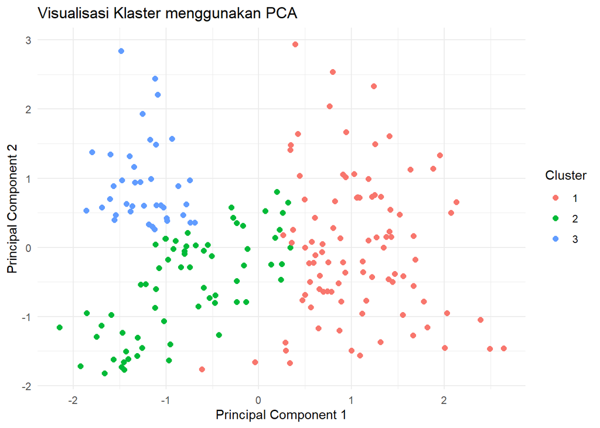

```r
# Visualisasi klaster menggunakan PCA
pca_result <- prcomp(data_scaled)
pca_data <- data.frame(pca_result$x, Cluster = as.factor(cluster_hclust))
ggplot(pca_data, aes(x = PC1, y = PC2, color = Cluster)) +
  geom_point(size = 2) +
  labs(title = "Visualisasi Klaster menggunakan PCA",
       x = "Principal Component 1",
       y = "Principal Component 2") +
  theme_minimal()
```

PCA membantu dalam mengurangi dimensi data sambil mempertahankan sebanyak mungkin varians. Dengan memplot dua komponen utama, kita dapat melihat bagaimana klaster-klaster terdistribusi dan apakah ada pemisahan yang jelas antara klaster-klaster tersebut. Berdasarkan visualisasi PCA, kita dapat mengamati bahwa klaster-klaster yang terbentuk memiliki pemisahan yang cukup baik, menunjukkan bahwa metode Ward’s efektif dalam mengelompokkan data berdasarkan karakteristiknya.

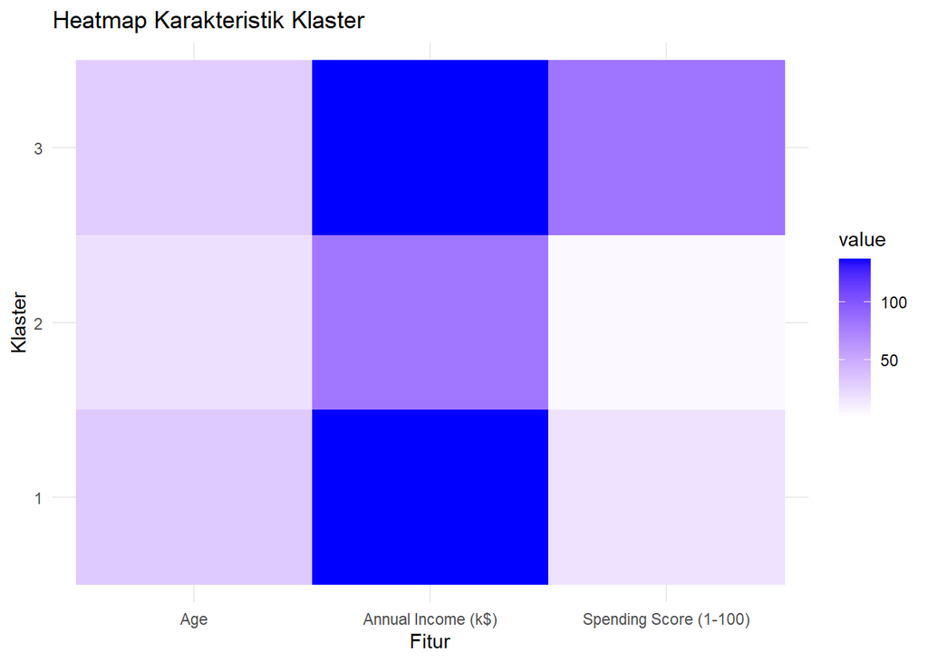

```r
# Visualisasi Heatmap
library(ggplot2)
library(reshape2)
# Pastikan hanya variabel numerik (selain kolom 'Cluster') yang digunakan
data_num <- data_clustered[, sapply(data_clustered, is.numeric)]
data_num$Cluster <- data_clustered$Cluster

# Ubah data menjadi format long
data_melted <- melt(data_num, id.vars = "Cluster")

# Buat heatmap
ggplot(data_melted, aes(x = variable, y = as.factor(Cluster), fill = value)) +
  geom_tile() +
  scale_fill_gradient(low = "white", high = "blue") +
  labs(title = "Heatmap Karakteristik Klaster",
       x = "Fitur",
       y = "Klaster") +
  theme_minimal()
```

Berdasarkan heatmap, kita dapat melihat pola karakteristik yang berbeda antara klaster-klaster. Misalnya, klaster 1 mungkin memiliki nilai tinggi pada fitur tertentu dibandingkan dengan klaster lainnya, menunjukkan perbedaan signifikan dalam karakteristik data.

# K-Means Clustering

## Menentukan Jumlah Klaster Optimal

Langkah awal dalam K-Means Clustering adalah menentukan jumlah klaster optimal (k) yang akan digunakan. Beberapa metode yang umum digunakan untuk menentukan k antara lain: 1. Elbow Method: Metode ini melibatkan plotting jumlah klaster terhadap total within-cluster sum of squares (WSS). Titik di mana penurunan WSS mulai melambat (membentuk “siku”) dianggap sebagai jumlah klaster optimal. 2. Silhouette Method: Metode ini mengukur seberapa mirip objek dengan klasternya sendiri dibandingkan dengan klaster lain. Nilai rata-rata silhouette yang lebih tinggi menunjukkan klaster yang lebih baik.

```r
library(factoextra)
library(dplyr)
library(tidyr)
library(scales)
library(RColorBrewer)
```

### Elbow Method

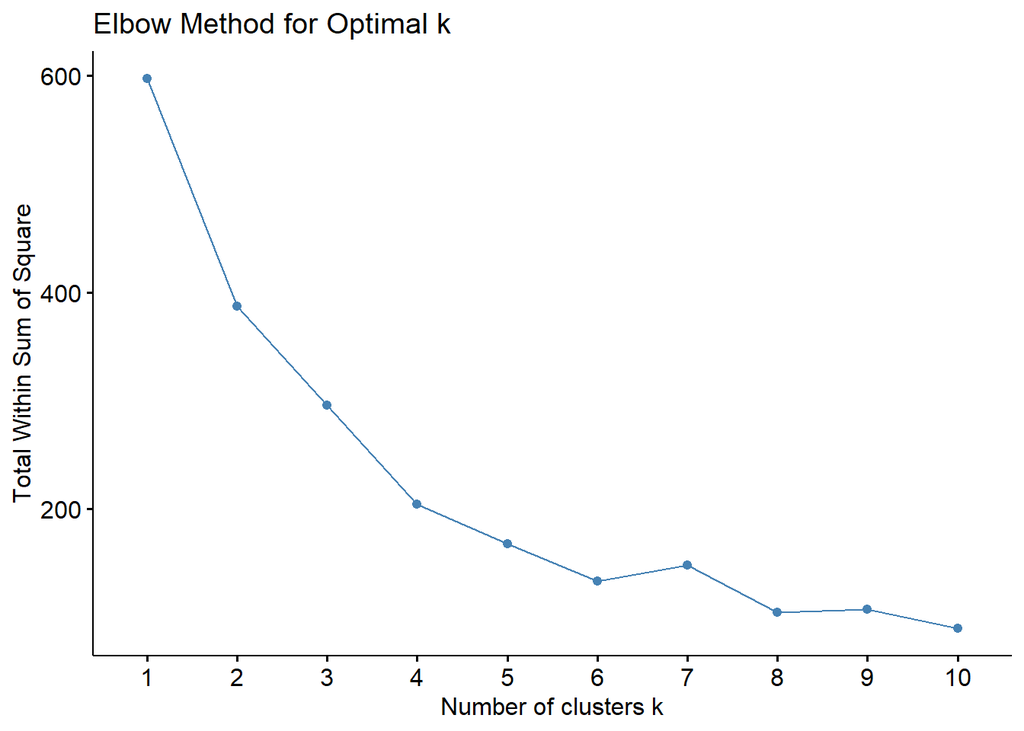

```r
fviz_nbclust(data_scaled, kmeans, method = "wss") +
  labs(title = "Elbow Method for Optimal k")
```

### Silhouette Method

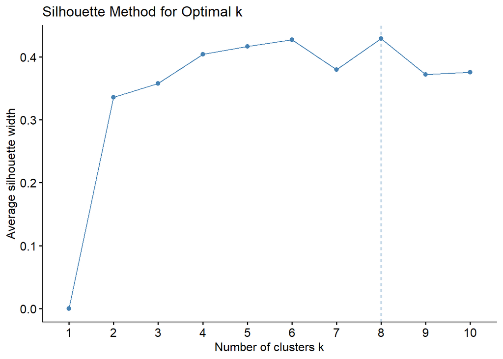

```r
fviz_nbclust(data_scaled, kmeans, method = "silhouette") +
  labs(title = "Silhouette Method for Optimal k")
```

## Menjalankan Algoritma K-Means dan Hasil clustering

Setelah menentukan jumlah klaster optimal (k), langkah selanjutnya adalah menjalankan algoritma K-Means pada data yang telah distandarisasi. Berikut adalah langkah-langkah untuk melakukan K-Means Clustering dengan k = 8

```r
set.seed(123)  # Untuk reproduktifitas
k <- 8  # Jumlah klaster optimal
kmeans_result <- kmeans(data_scaled, centers = k, nstart = 25)
table(kmeans_result$cluster)
```

```
##
##  1  2  3  4  5  6  7  8
## 33 32 20 20 20 39 14 22
```

## Komponen Hasil K-Means

```r
names(kmeans_result)
```

```
## [1] "cluster"      "centers"      "totss"        "withinss"     "tot.withinss"
## [6] "betweenss"    "size"         "iter"         "ifault"
```

Beberapa komponen penting yang dihasilkan oleh objek kmeans antara lain: 1. cluster: Vektor yang menunjukkan klaster yang ditugaskan untuk setiap objek dalam data 2. centers: Matriks yang berisi pusat klaster (centroids) untuk setiap klaster 3. tot.withinss: Total within-cluster sum of squares, yang mengukur seberapa baik klaster terbentuk 4. size: Vektor yang menunjukkan jumlah objek dalam setiap klaster 5. ifault: Informasi tentang iterasi yang dilakukan selama proses K-Means 6. totss: Total sum of squares dari data asli 7. betweenss: Between-cluster sum of squares, yang mengukur variasi antar klaster 8. iter: Jumlah iterasi yang dilakukan untuk mencapai konvergensi 9. withinss: Vektor yang menunjukkan within-cluster sum of squares untuk setiap klaster

```r
kmeans_result$centers
```

```
##          Age Annual Income (k$) Spending Score (1-100)
## 1 -1.0218509         -0.2289971            -0.03942846
## 2  0.5901457         -0.1902742            -0.09245447
## 3  0.4688952         -1.3291594            -1.22562679
## 4  1.8612633         -0.2821275            -0.01355353
## 5  0.7266085          1.0580733            -1.20239216
## 6 -0.4408110          0.9891010             1.23640011
## 7 -0.5517316          1.0936996            -1.42671699
## 8 -0.9719569         -1.3262173             1.12934389
```

```r
kmeans_result$tot.withinss
```

```
## [1] 103.2693
```

```r
kmeans_result$size
```

```
## [1] 33 32 20 20 20 39 14 22
```

```r
kmeans_result$iter
```

```
## [1] 3
```

```r
kmeans_result$withinss
```

```
## [1] 14.406726  9.645699 19.809395  4.461166 12.984588 22.362673 11.407191
## [8]  8.191823
```

```r
kmeans_result$betweenss
```

```
## [1] 493.7307
```

## Evaluasi Klaster K-Means

Beberapa metrik evaluasi klaster yang dapat digunakan untuk menilai kualitas hasil klastering K-Means antara lain: 1. Silhouette Score: Mengukur seberapa mirip objek dengan klasternya sendiri dibandingkan dengan klaster lain. Nilai berkisar dari -1 hingga 1, di mana nilai yang lebih tinggi menunjukkan klaster yang lebih baik. 2. Dunn Index: Mengukur rasio antara jarak minimum antar klaster dengan diameter maksimum klaster. Nilai yang lebih tinggi menunjukkan klaster yang lebih baik. 3. Calinski-Harabasz Index: Mengukur rasio antara variansi antar klaster dan variansi dalam klaster. Nilai yang lebih tinggi menunjukkan klaster yang lebih baik.

```r
library(cluster)
library(clusterCrit)
distance_matrix <- dist(data_scaled)

silhouette_values_kmeans <- silhouette(kmeans_result$cluster, distance_matrix)
avg_silhouette_kmeans <- mean(silhouette_values_kmeans[, 3])
cat("Average Silhouette Score (K-Means):", avg_silhouette_kmeans, "\n")
```

```
## Average Silhouette Score (K-Means): 0.4100894
```

```r
# Menghitung Dunn Index
dunn_index_kmeans <- intCriteria(
  as.matrix(data_scaled),
  as.integer(kmeans_result$cluster),
  c("Dunn")
)$dunn
cat("Dunn Index (K-Means):", dunn_index_kmeans, "\n")
```

```
## Dunn Index (K-Means): 0.09137426
```

```r
# Menghitung Calinski-Harabasz Index
ch_index_kmeans <- intCriteria(
  as.matrix(data_scaled),
  as.integer(kmeans_result$cluster),
  c("Calinski_Harabasz")
)$calinski_harabasz
cat("Calinski-Harabasz Index (K-Means):", ch_index_kmeans, "\n")
```

```
## Calinski-Harabasz Index (K-Means): 131.1361
```

## Karakteristik Klaster K-Means

```r
data_kmeans_clustered <- data1 %>%
  mutate(Cluster = as.factor(kmeans_result$cluster))
# Melihat profil rata-rata setiap klaster
cluster_profiles_kmeans <- data_kmeans_clustered %>%
  group_by(Cluster) %>%
  summarise(across(where(is.numeric), mean, na.rm = TRUE))
print(cluster_profiles_kmeans)
```

```
## # A tibble: 8 × 4
##   Cluster   Age `Annual Income (k$)` `Spending Score (1-100)`
##   <fct>   <dbl>                <dbl>                    <dbl>
## 1 1        24.6                 54.5                     49.2
## 2 2        47.1                 55.6                     47.8
## 3 3        45.4                 25.6                     18.6
## 4 4        64.8                 53.2                     49.8
## 5 5        49                   88.4                     19.2
## 6 6        32.7                 86.5                     82.1
## 7 7        31.1                 89.3                     13.4
## 8 8        25.3                 25.7                     79.4
```

## Visualisasi Klaster K-Means

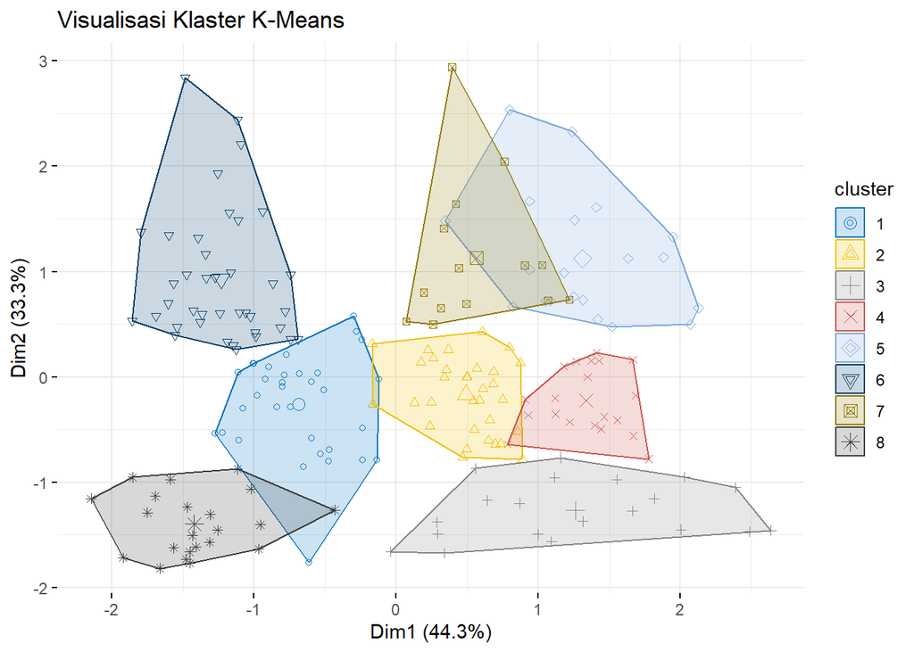

```r
fviz_cluster(kmeans_result, data = data_scaled,
             geom = "point",
             ellipse.type = "convex",
             palette = "jco",
             ggtheme = theme_minimal(),
             main = "Visualisasi Klaster K-Means")
```

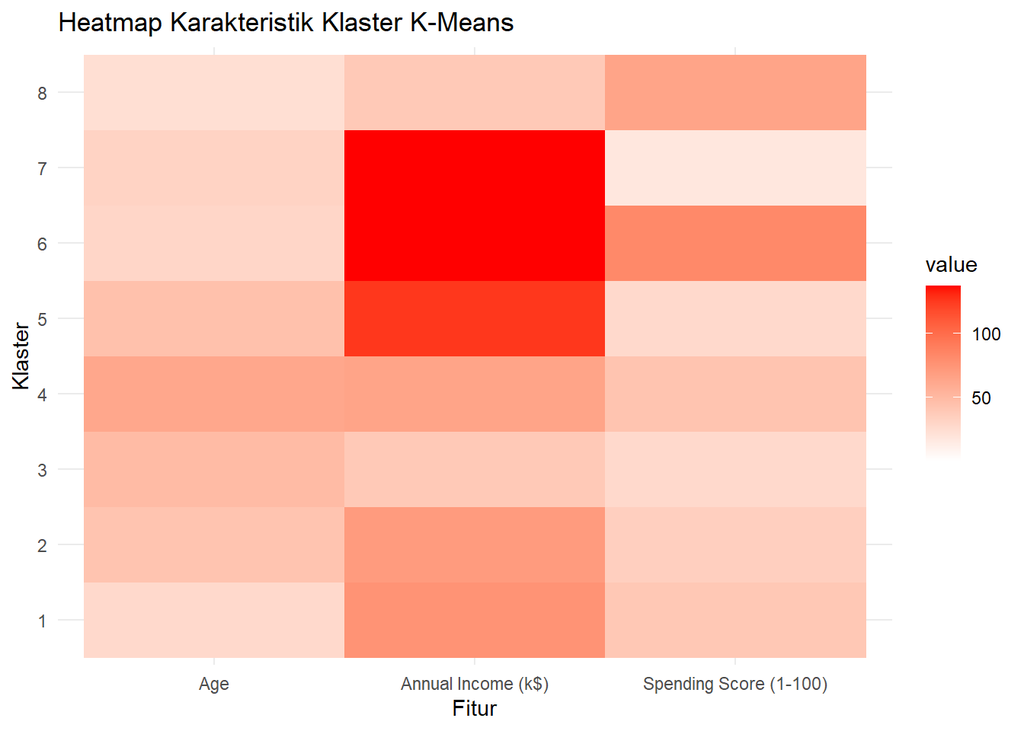

```r
# Visualisasi Heatmap untuk K-Means
library(ggplot2)
library(reshape2)
# Pastikan hanya variabel numerik (selain kolom 'Cluster') yang digunakan
data_num_kmeans <- data_kmeans_clustered[, sapply(data_kmeans_clustered, is.numeric)]
data_num_kmeans$Cluster <- data_kmeans_clustered$Cluster
# Ubah data menjadi format long
data_melted_kmeans <- melt(data_num_kmeans, id.vars = "Cluster")
# Buat heatmap
ggplot(data_melted_kmeans, aes(x = variable, y = as.factor(Cluster), fill = value)) +
  geom_tile() +
  scale_fill_gradient(low = "white", high = "red") +
  labs(title = "Heatmap Karakteristik Klaster K-Means",
       x = "Fitur",
       y = "Klaster") +
  theme_minimal()
```

## Perbandingan Hasil Klastering

Setelah melakukan clustering menggunakan metode Hierarchical Clustering (Ward’s) dan K-Means, kita dapat membandingkan hasil kedua metode tersebut.

```r
# Membandingkan hasil berbagai metode
comparison_table <- data.frame(
  Method = c("Hierarchical (Ward's)", "K-Means"),
  Silhouette_Score = c(avg_silhouette, avg_silhouette_kmeans),
  Dunn_Index = c(dunn_index, dunn_index_kmeans),
  Calinski_Harabasz_Index = c(ch_index, ch_index_kmeans)
)
print(comparison_table)
```

```
##                  Method Silhouette_Score Dunn_Index Calinski_Harabasz_Index
## 1 Hierarchical (Ward's)        0.3214887 0.06719828                88.10174
## 2               K-Means        0.4100894 0.09137426               131.13611
```

Berdasarkan tabel perbandingan di atas, kita dapat melihat bagaimana kedua metode clustering berkinerja berdasarkan metrik evaluasi yang telah dihitung. Misalnya, jika Hierarchical Clustering memiliki nilai Silhouette Score yang lebih tinggi dibandingkan dengan K-Means, ini menunjukkan bahwa klaster yang terbentuk oleh Hierarchical Clustering lebih baik dalam hal pemisahan antar klaster. Dan sebaliknya